# Inferential Statistics

307312 Applied Statistics — Masters Level

Read each topic and run the **Try this in R** examples beside it.

- Open the top-level course folder in Positron and keep the R Console at that project root.
- Run the R cells in order; later comparisons and regression checks reuse the data and models introduced earlier.
- CSVs are supplied under `data/inferential-statistics/`. Install the recommended R package MASS if needed for the distribution-fitting example.

## 3.1 Introduction to Probability Distributions

### Contents

1. **Probability distributions:** random variables, discrete and continuous distributions, expected value and variance, normal distribution and Z-scores.
2. **Estimation:** sampling, point estimates, standard errors and confidence intervals.
3. **Hypothesis testing:** hypotheses, significance and p-values; tests for means and proportions, chi-square tests and ANOVA.
4. **Regression:** simple and multiple linear regression, interpretation, prediction and model assumptions.

### Introduction to Inferential Statistics

**Definition**: Inferential statistics is the branch of statistics that involves making inferences or predictions about a population based on sample data.

**Objective**: The main goal of inferential statistics is to draw conclusions, make predictions, or test hypotheses about a population using information obtained from a sample.

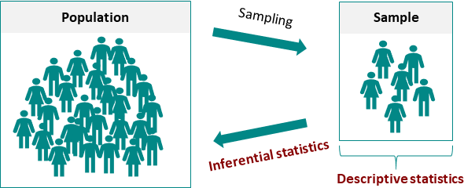

### Inferential Statistics Uses

Inferential statistics is used in various fields and contexts to make predictions, draw conclusions, and make inferences about populations based on sample data. Here are some common areas and applications where inferential statistics is used:

**Scientific Research**: Inferential statistics is fundamental in scientific research across disciplines such as biology, physics, chemistry, and environmental science. Researchers use statistical tests to analyze data and draw conclusions about hypotheses.

**Business and Economics**: Businesses use inferential statistics for market research, sales forecasting, quality control, and decision-making. Econometric models are employed to analyze economic data and make policy recommendations.

**Healthcare and Medicine**: Medical researchers and healthcare professionals use inferential statistics to study the effectiveness of treatments, analyze patient data, and draw conclusions about disease prevalence. Clinical trials rely heavily on inferential statistics.

**Education**: In the field of education, inferential statistics are used to assess the effectiveness of teaching methods, evaluate standardized test scores, and make policy decisions about educational programs.

**Market Research and Data Analysis**: Market researchers use inferential statistics to make predictions about consumer preferences, market trends, and the impact of marketing campaigns.

**Finance and Investment**: In finance, inferential statistics are used to assess investment risk, analyze stock market data, and estimate future asset prices. Portfolio optimization and risk management rely on statistical modeling.

**Criminal Justice and Criminology**: Researchers and law enforcement agencies use inferential statistics to analyze crime data, study crime patterns, and evaluate the effectiveness of criminal justice programs.

**Sports and Athletics**: In sports analytics, inferential statistics are used to analyze player performance, predict game outcomes, and make strategic decisions in sports management.

### Introduction to Inferential Statistics

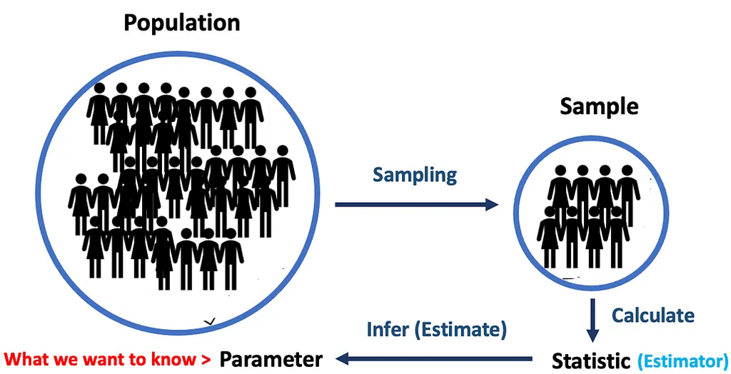

**Key** **Concepts**:

**Population**: The entire group of individuals or items of interest that we want to study.

**Sample**: A subset of the population from which data is collected and analyzed.

**Parameter**: A numerical characteristic of a population (e.g., mean, proportion).

**Statistic**: A numerical characteristic of a sample (e.g., sample mean, sample proportion).

https://medium.com/towards-data-science/what-is-p-value-370056b8244d

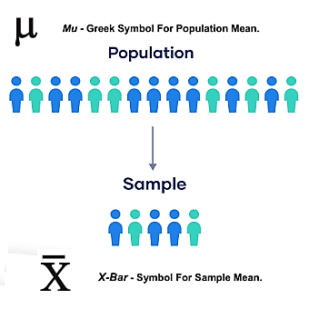

### Types of Inferential Statistics

- Estimation

Point Estimation: Provides a single best guess about a population parameter (e.g., the mean, proportion).

Interval Estimation (Confidence Intervals): Gives a range of values for a population parameter with a certain level of confidence.

- Hypothesis Testing

A statistical method that uses sample data to evaluate a hypothesis about a population parameter, determining whether there is sufficient evidence to accept or reject a given hypothesis about that population.

- Regression Analysis

Assesses the linear relationship between one continuous dependent variable and one or more independent variables.

### Introduction to Random Variables

Understanding the Basics of Probability in Statistics

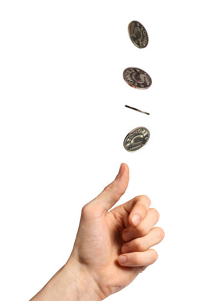

### What is a Random Variable?

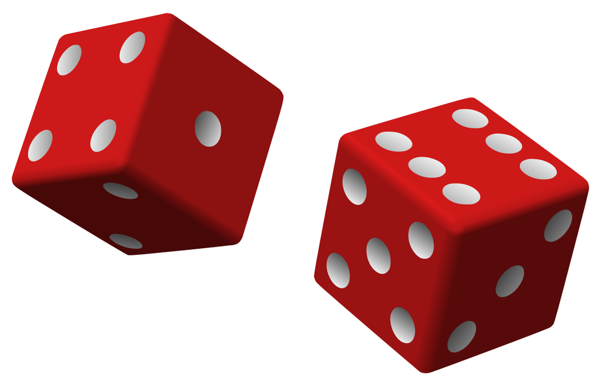

A random variable is a variable whose possible values are outcomes of a random process.

A random process is a process or event or where the outcome cannot be predicted with certainty, and each possible outcome has an associated probability.

It can be classified as discrete or continuous depending on the range of values that it assumes.

A discrete random variable assumes a countable number of distinct values, whereas a continuous random variable is characterized by measurable (uncountable) values.

Example: Flipping a coin (discrete), measuring the amount of rain in a day (continuous)

### Discrete Random Variables

A Discrete Random Variable is a variable which can take on only a countable number of distinct values like 0, 1, 2, 3, 4, 5…100, 1 million, etc.

Examples of discrete random variables:

The number of cars that passes through a toll booth everyday in a given day.

The number of times a coin lands on tails after being flipped 20 times.

The number of defective widgets in a box of 50 widgets.

Number of Calls Received by a Call Center.

Number of Emails Received in a Day

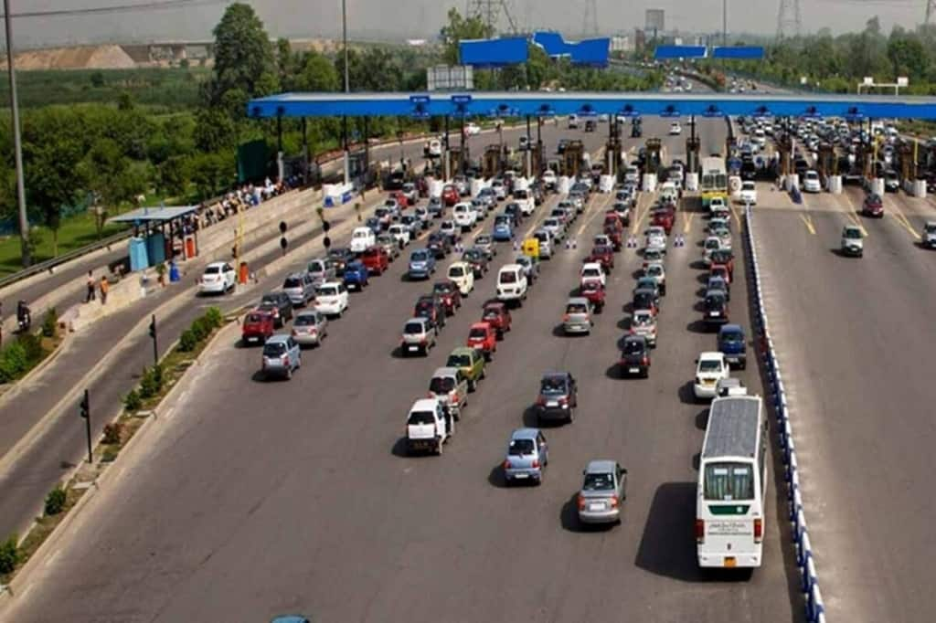

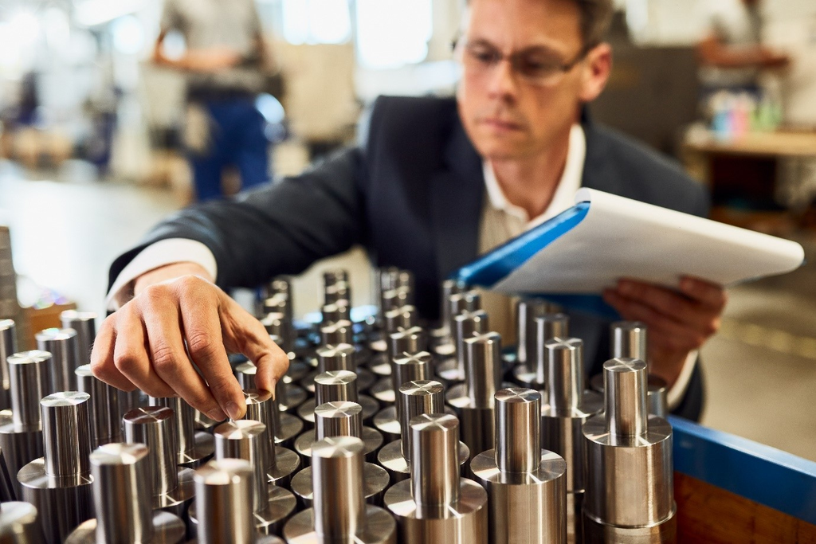

### Continuous Random Variables

[figure not shown]

A Continuous Random Variable is a variable which can take on an infinite number of possible values.

Examples of continuous random variables:

Business profits.

The height of a tree.

The weight of an animal.

Arrival times of airlines.

Time required to run a marathon.

The weight of a chocolate bar on a production line.

[figure not shown]

### Introduction to Probability Distributions

Discrete and Continuous Probability Distributions

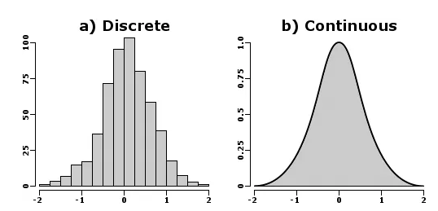

### Introduction to Probability Distributions

Probability distributions are mathematical functions that describe the likelihood of various outcomes in a statistical experiment.

They provide a mathematical framework for modeling random phenomena.

Discrete vs. Continuous Probability Distributions

Discrete distributions: Outcomes are countable and have finite or countably infinite values.

Continuous distributions: Outcomes are uncountable and have an infinite range of values.

For a probability distribution to be valid, it must satisfy the following two criteria:

The probability for each outcome must be between 0 and 1.

The sum of all the probabilities must add up to 1.

### Discrete Uniform Distribution

Equal probability is assigned to each integer from $a$ to $b$, where $a$ and $b$ are integers and $a \le b$.

- **Notation:** $X \sim U\{a, a+1,\ldots,b\}$; there are $k=b-a+1$ possible outcomes.
- **Probability mass function:** $P(X=x)=\dfrac{1}{b-a+1}=\dfrac{1}{k}$ for $x\in\{a,\ldots,b\}$; zero otherwise.
- **Expected value:** $E(X)=\dfrac{a+b}{2}$.
- **Variance:** $\operatorname{Var}(X)=\dfrac{(b-a+1)^2-1}{12}$.

**Example — a fair six-sided die:** $a=1$, $b=6$. Each face has probability $1/6$, $E(X)=3.5$ and $\operatorname{Var}(X)=35/12\approx2.917$. The expected value is the long-run average; it need not be a possible single outcome.

### Discrete Uniform – PMF Uses

**Calculating individual probabilities**

Example: For a fair die (U(1,6)), the probability of rolling a 3 is:

P(X = 3) = 1/(6-1+1) = 1/6 ≈ 0.167

**Finding probabilities of events**

For multiple outcomes: Sum the individual probabilities

Example: Probability of rolling an even number:

P(X ∈ {2,4,6}) = P(X=2) + P(X=4) + P(X=6) = 1/6 + 1/6 + 1/6 = 3/6 = 0.5

**Range probabilities**

Example: Probability of rolling between 2 and 5 inclusive:

P(2 ≤ X ≤ 5) = (5-2+1)/(6-1+1) = 4/6 = 0.667

#### Try this in R

- **Purpose:** Calculate probabilities for a fair die.
- **Before running:** `1:6` lists the six values; `rep(1/6,6)` gives each the same probability. `sum()` adds selected probabilities. `%in%` tests membership; `&` requires both comparisons; `>=` and `<=` include the endpoints.

```r
# rep() assigns equal mass to the six fair-die outcomes; sum() adds the selected probabilities.
# %in% selects even outcomes; the second selection includes both endpoints 2 and 5.
outcomes <- 1:6
probability <- rep(1/6, 6)
c(three = probability[3], even = sum(probability[outcomes %in% c(2,4,6)]),
  between_2_and_5 = sum(probability[outcomes >= 2 & outcomes <= 5]))
```

```
          three            even between_2_and_5
      0.1666667       0.5000000       0.6666667
```

**Read the result:** One specified face has probability 1/6, even faces 1/2 and values 2 through 5 have probability 2/3. Equal probabilities are assumed.

### Binomial Distribution

The binomial distribution models the **number of successes in $n$ independent Bernoulli trials**, each with the same success probability $p$. A Bernoulli trial has two outcomes: success or failure.

- **Notation:** $X\sim\operatorname{Binomial}(n,p)$; $X$ counts successes.
- **Parameters:** $n$ is the fixed number of trials; $p$ is the success probability on each trial.
- **Probability mass function:**

$$P(X=x)=\binom{n}{x}p^x(1-p)^{n-x},\qquad x=0,1,\ldots,n.$$

Here $\binom{n}{x}$ counts the ways to choose $x$ successes among $n$ trials; $1-p$ is the failure probability.

- **Expected value:** $E(X)=np$, the average number of successes over repeated sets of $n$ trials.
- **Variance:** $\operatorname{Var}(X)=np(1-p)$, the spread of the success count in squared count units.

**Example:** If 80 cars each independently have a 2% defect probability, $n=80$ and $p=0.02$. Counting a defect as a “success”, $E(X)=80(0.02)=1.6$ defective cars per group of 80 on average; $\operatorname{Var}(X)=80(0.02)(0.98)=1.568$.

Example: The defect ratio in a car factory is 2% and the factory produces 80 cars in a month,. We can use the binomial distribution to answer questions similar to:

what is the probability that exactly 2 cars are defective?

what is the probability that less than 2 cars are defective?

what is the probability that more than 2 cars are defective?

What is the probability that all cars produced in a month will have no defects?

[figure not shown]

#### Try this in R

- **Purpose:** Count defective cars among the stated 80 independent cars.
- **Before running:** `dbinom(x, size, prob)` gives an exact binomial count probability. `pbinom(q, size, prob)` gives the probability at or below cutoff q; `lower.tail=FALSE` instead gives above q. `size=80` is the trial count and `prob=0.02` is the per-car defect chance. Thus fewer than two uses cutoff 1.

```r
# dbinom() gives exact counts; pbinom() gives cumulative probabilities for 80 independent cars.
# less than 2 means X<=1; lower.tail=FALSE computes P(X>2), using the stated defect probability 0.02.
c(exactly_2 = dbinom(2, size=80, prob=0.02), less_than_2 = pbinom(1,80,0.02),
  more_than_2 = pbinom(2,80,0.02,lower.tail=FALSE), no_defects = dbinom(0,80,0.02))
```

```
  exactly_2 less_than_2 more_than_2  no_defects
  0.2614454   0.5229735   0.2155811   0.1986489
```

**Read the result:** Interpret each labelled probability as a batch event under the independent, common-probability model; an expected count is not a guaranteed batch result.

### The Binomial Distribution

What is the probability of having 2 Heads ONLY out of 10 trials, knowing that the probability of Head = 50%?

A binomial distribution is symmetric when p = 0.5 and skewed when p is close to 0 or 1. A normal approximation improves when both np and n(1 − p) are sufficiently large; increasing n alone is not a universal guarantee.

#### Try this in R

- **Purpose:** See how the number of trials $n$ and success probability $p$ affect the binomial shape.
- **Before running:** `c()` combines values into vectors; `[i]` selects the ith value. `1:4` lists the four panel numbers, and the `for` loop repeats the plotting steps for each panel. `0:n` lists every possible success count from zero to $n$.
- `dbinom(x, size, prob)` gives the probability at each count `x`; `size` is $n$ and `prob` is $p$. These are theoretical probabilities, not simulated data.
- `par(mfrow = c(2, 2))` arranges two rows and two columns; `mar` sets bottom, left, top and right margins. Assigning its result to `old_par` saves the old settings; `par(old_par)` restores them.
- `plot(x, y)` draws counts against probabilities. `type = "h"` draws vertical probability masses, `lwd` sets line width, `col` sets colour, `xlab`/`ylab` label axes and `main` sets a title. `paste()` joins the title text and parameter values.
- `if` runs the highlighted step only when both conditions hold: `==` tests equality and `&&` means “and”. `segments()` draws the burgundy line from `(x0, y0)` to `(x1, y1)` at two successes.

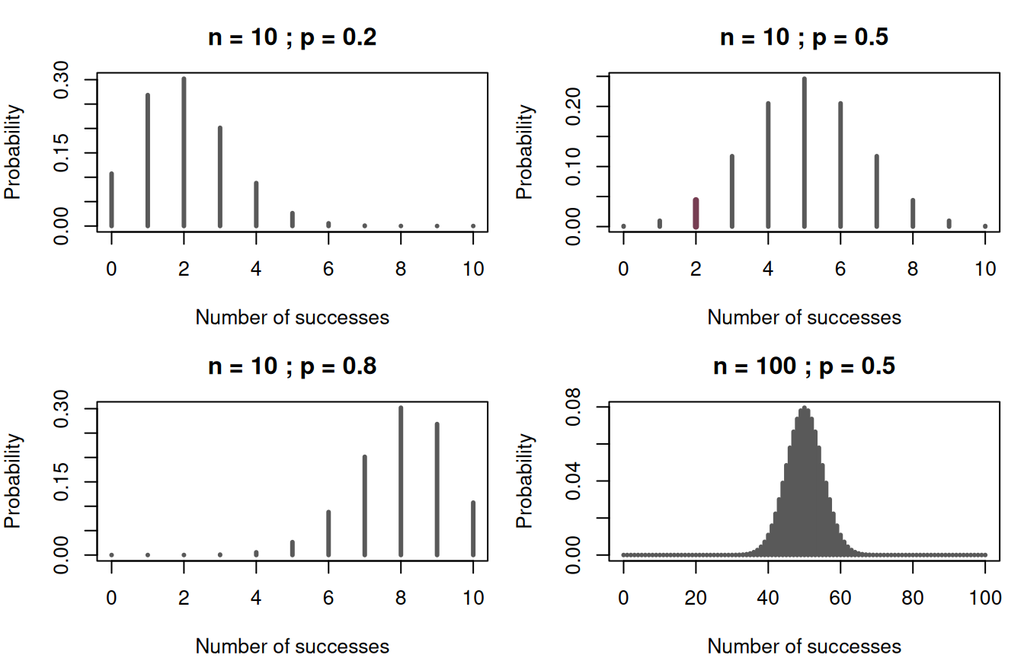

```r
# Compare success probabilities at n = 10, then increase n to 100.
# Save the current plotting layout so it can be restored afterwards.
old_par <- par(mfrow = c(2, 2), mar = c(4, 4, 3, 1))
trial_counts <- c(10, 10, 10, 100)
success_probs <- c(0.2, 0.5, 0.8, 0.5)
for (i in 1:4) {
  n <- trial_counts[i]
  p <- success_probs[i]
  x <- 0:n
  probabilities <- dbinom(x = x, size = n, prob = p)
  plot(x = x, y = probabilities, type = "h", lwd = 3,
       col = "#595959", xlab = "Number of successes",
       ylab = "Probability", main = paste("n =", n, "; p =", p))
  if (n == 10 && p == 0.5) {
    # Highlight the question: exactly two heads in ten fair tosses.
    segments(x0 = 2, y0 = 0, x1 = 2,
             y1 = dbinom(x = 2, size = n, prob = p),
             col = "#763D52", lwd = 4)
  }
}
```

```r
par(old_par)
dbinom(x = 2, size = 10, prob = 0.5)
```

```
[1] 0.04394531
```

**Read the result:** At $n=10$, $p=0.2$ gives right skew, $p=0.5$ gives symmetry, and $p=0.8$ gives left skew. At $n=100$, $p=0.5$, the discrete shape is more bell-like and centred at $np=50$. In the ten-toss fair-coin panel, the burgundy line marks exactly two heads: probability 0.0439453, about 4.39%. Compare the axis scales as well as the shapes.

### Discrete Probability Distributions The Poisson Distribution

- Poisson Distribution can be used to model the number of times an event occurs within a specified time period or in a given space.
- It's particularly useful for estimating the likelihood of rare events over short intervals.
- The key feature of the Poisson distribution is that it is defined by just one parameter, **λ** (lambda), which represents the average rate at which events occur.

**Poisson probability mass function**

$$P(X=x)=\frac{\lambda^x e^{-\lambda}}{x!},\qquad x=0,1,2,\ldots.$$

- $X$ counts occurrences in a specified time interval or region.
- $\lambda>0$ is the expected number of occurrences in that interval or region.
- $e\approx2.71828$ is Euler’s number; $x!$ is the factorial of $x$, with $0!=1$.
- **Expected value:** $E(X)=\lambda$.
- **Variance:** $\operatorname{Var}(X)=\lambda$; the standard deviation is $\sqrt{\lambda}$.
- **Model assumptions:** occurrences are independent, with a constant rate over the interval or region.

**Example:** At an average of 1,000 calls per hour, a Poisson model has $\lambda=1000$ for a one-hour interval. Its expected count is 1,000 calls, variance 1,000 calls squared, and standard deviation approximately 31.62 calls.

Example: Suppose that Zein call center receives 1000 calls/hour on average, and that data center has a capacity of receiving 1100 calls/hours.

Use the Poisson Distribution to find the probability that the number of calls will exceed the call center's capacity, which will require additional temporary staff?

[figure not shown]

#### Try this in R

- **Purpose:** Find the probability of exceeding the stated call-centre capacity.
- **Before running:** `ppois(q=1100, lambda=1000, lower.tail=FALSE)` gives the chance of more than 1,100 events when the expected count is 1,000 per hour. The cutoff and rate refer to the same hour.

```r
# ppois() uses the stated one-hour mean lambda=1000 under a homogeneous Poisson model.
# lower.tail=FALSE gives P(X>1100), so exactly 1100 calls does not exceed capacity.
ppois(1100, lambda=1000, lower.tail=FALSE)
```

```
[1] 0.000867641
```

**Read the result:** This is the chance of exceeding the threshold under the Poisson model; exactly 1,100 is excluded. A probability alone does not determine staffing.

### Poisson Distribution

A Poisson distribution models counts, not continuous measurements. Small λ gives a right-skewed shape. As λ increases, it becomes more symmetric and approximately bell-shaped, while its possible outcomes remain whole numbers.

#### Try this in R

- **Purpose:** Compare a visibly skewed Poisson distribution ($\lambda=2$) with the more symmetric $\lambda=20$ case, and calculate the probability of exactly 15 events.
- **Before running:** `dpois(x, lambda)` gives the probability at each whole-number count `x`; `lambda` is the expected count for the interval. `qpois(p = 0.999, lambda)` gives the smallest count whose cumulative probability is at least 99.9%, setting a practical plotting limit. The distribution itself continues beyond that limit.
- `c(2, 20)` combines the two parameter values; the `for` loop draws one panel per value. `0:` constructs the sequence of counts from zero to the chosen limit.
- `par(mfrow = c(1, 2))` places two panels side by side; `mar` sets the bottom, left, top and right margins. Save these settings in `old_par`, then restore the previous layout with `par(old_par)`.
- `plot(x, y)` draws counts against probabilities; `type = "h"` uses separate vertical masses, `lwd` sets width, `col` sets colour, `xlab`/`ylab` label axes and `main` supplies a title. `paste()` joins the title text with the parameter value.
- `if (lambda == 20)` highlights only the second panel: `==` tests equality. `segments()` draws the burgundy line from `(x0, y0)` to `(x1, y1)` at 15 events.

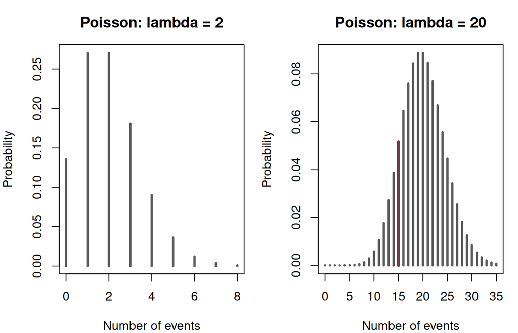

```r
# Compare a small expected count with the calculator example, lambda = 20.
old_par <- par(mfrow = c(1, 2), mar = c(4, 4, 3, 1))
lambda_values <- c(2, 20)
for (lambda in lambda_values) {
  # Display counts through the 99.9th percentile; a small right tail is omitted.
  x <- 0:qpois(p = 0.999, lambda = lambda)
  probabilities <- dpois(x = x, lambda = lambda)
  plot(x = x, y = probabilities, type = "h", lwd = 3,
       col = "#595959", xlab = "Number of events",
       ylab = "Probability", main = paste("Poisson: lambda =", lambda))
  if (lambda == 20) {
    segments(x0 = 15, y0 = 0, x1 = 15,
             y1 = dpois(x = 15, lambda = lambda),
             col = "#763D52", lwd = 4)
  }
}
```

[output not shown]

```r
par(old_par)
dpois(x = 15, lambda = 20)
```

```
[1] 0.05164885
```

**Read the result:** The $\lambda=2$ panel is right-skewed; the $\lambda=20$ panel looks more bell-shaped. Both show **discrete Poisson probabilities**, not a continuous normal density. At $\lambda=20$, the burgundy line marks $P(X=15)\approx0.05165$, or 5.16%. Compare the different axis scales too.

### Continuous Probabilities Distributions

### The Continuous Uniform Distribution

A continuous uniform distribution has **constant probability density** on the interval $[a,b]$, where $a<b$. Equal-length subintervals have equal probability.

- **Notation:** $X\sim U(a,b)$.
- **Density:** $f(x)=\dfrac{1}{b-a}$ for $a\le x\le b$, and zero otherwise.
- **Expected value:** $E(X)=\dfrac{a+b}{2}$.
- **Variance:** $\operatorname{Var}(X)=\dfrac{(b-a)^2}{12}$; standard deviation $\sigma=\dfrac{b-a}{\sqrt{12}}$.
- **Interval probability:** $P(c\le X\le d)=\dfrac{d-c}{b-a}$ for $a\le c\le d\le b$.
- **One exact value:** $P(X=x)=0$. Probabilities are areas, not density heights.

**Example — delivery time from 2 to 5 days:** $E(X)=3.5$ days, variance $0.75$ days squared. Delivery between 3 and 4 days has probability $(4-3)/(5-2)=1/3$.

### The Continuous Uniform Distribution Business Cases Studies

**Inventory Arrival**

A retailer's deliveries arrive uniformly between 8 AM and 12 PM.

**Manufacturing**

A machine produces widgets with diameters uniformly distributed between 9.8mm and 10.2mm.

**Delivery arrivals: $X\sim U(8,12)$, in hours on the clock**

- **Mean arrival time:** $E(X)=(8+12)/2=10$, or 10 AM.
- **Before 9 AM:** $P(X<9)=(9-8)/(12-8)=0.25=25\%$.
- **Planning:** be ready from 8 AM. The uniform model gives the same arrival probability to every one-hour interval; 10 AM is not a predicted peak.

**Widget diameter: $X\sim U(9.8,10.2)$, in millimetres**

- **Mean diameter:** $E(X)=(9.8+10.2)/2=10.0$ mm.
- **Above 10.1 mm:** $P(X>10.1)=(10.2-10.1)/(10.2-9.8)=0.25=25\%$.
- **Variance:** $\operatorname{Var}(X)=(10.2-9.8)^2/12\approx0.01333$ mm squared.
- **Quality interpretation:** under this model, 25% of widgets exceed 10.1 mm. This is not a defect rate unless 10.1 mm is the specified upper limit.

#### Try this in R

- **Purpose:** Apply the two uniform models.
- **Before running:** `punif(q, min, max)` returns the probability at or below cutoff `q`, with interval endpoints `min` and `max`. `lower.tail = FALSE` returns the probability above the cutoff. `c()` combines the labelled results.
- `par(mfrow = c(1, 2))` places two charts side by side. `mar` sets bottom, left, top and right margins; save previous settings as `old_par` and restore them using `par(old_par)`.
- `plot(x, y, type = "n")` sets up axes without drawing data; the two-element `x` and `y` vectors set the displayed ranges. `xlab`, `ylab` and `main` supply axis labels and the title.
- `rect()` shades a rectangle bounded by `xleft`, `xright`, `ybottom` and `ytop`. `col` sets its fill; `border = NA` omits the border. `segments()` draws the horizontal density from `(x0, y0)` to `(x1, y1)`; `lwd` sets its width.
- Arrival values are clock hours; diameters are millimetres. A density can exceed 1: its **area**, rather than its height, must total 1.

```r
# Exact interval probabilities from the two stated continuous uniform models.
c(arrival_before_9 = punif(q = 9, min = 8, max = 12),
  diameter_above_10_1 = punif(q = 10.1, min = 9.8, max = 10.2,
                             lower.tail = FALSE))
```

```
   arrival_before_9 diameter_above_10_1
               0.25                0.25
```

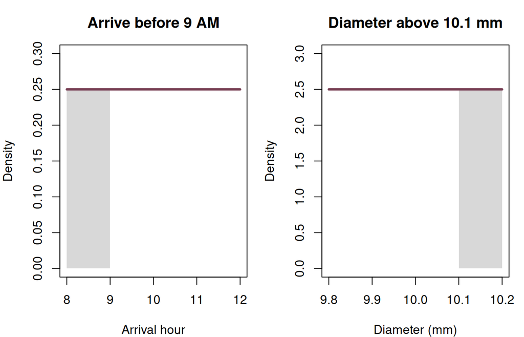

```r
# Plot density heights; shaded areas represent the required probabilities.
old_par <- par(mfrow = c(1, 2), mar = c(4, 4, 3, 1))
plot(x = c(8, 12), y = c(0, 0.30), type = "n",
     xlab = "Arrival hour", ylab = "Density", main = "Arrive before 9 AM")
rect(xleft = 8, ybottom = 0, xright = 9, ytop = 1 / (12 - 8),
     col = "#D8D8D8", border = NA)
segments(x0 = 8, y0 = 0.25, x1 = 12, y1 = 0.25,
         col = "#763D52", lwd = 3)
plot(x = c(9.8, 10.2), y = c(0, 3), type = "n",
     xlab = "Diameter (mm)", ylab = "Density", main = "Diameter above 10.1 mm")
rect(xleft = 10.1, ybottom = 0, xright = 10.2, ytop = 1 / (10.2 - 9.8),
     col = "#D8D8D8", border = NA)
segments(x0 = 9.8, y0 = 2.5, x1 = 10.2, y1 = 2.5,
         col = "#763D52", lwd = 3)
```

```r
par(old_par)
```

**Read the result:** Both probabilities are 0.25. Uniformity means equal-length intervals have equal probability; the midpoint is not a peak.

### The Normal Distribution

[figure not shown]

The normal distribution is the most extensively used probability distribution in statistical work.

It is also known as the Gaussian distribution and the Bell Curve.

The x-axis represents the outcomes of the normal process (e.g. students scores, heights, salaries…etc.).

The AREA UNDER THE CURVE represents the probability of the outcome.

The normal distribution has a symmetric distribution where most of the observations cluster around the central peak.

Theoretically, a normal random variable can assume any value between minus infinity and plus infinity.

Normal Distribution Main Features:

Symmetrically distributed

Long Tails / Bell Shaped

Mean/ Mode and Median are the same

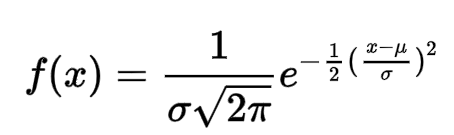

### Parameters of the Normal Distribution

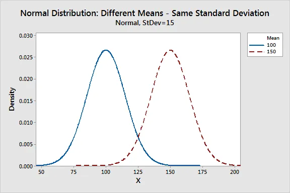

The normal distribution is completely described by two parameters, the Mean and the Standard Deviation.

Where X is a continuous random variable (the expected outcome of a continuous random process).

μ = The Mean of the Outcomes of the Random Process.

σ = The Standard Deviation of the Outcomes of the Random Process.

π is approximately 3.14159.

e is approximately 2.71828.

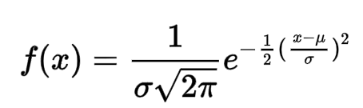

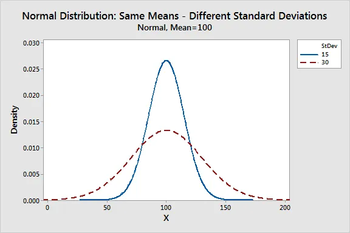

### The Empirical Rule for the Normal Distribution

The Empirical Rule describes how data (continuous outcomes) are spread in a normal distribution.

The proportion of the area that falls under the curve between two points on a probability distribution indicates the probability that a value will fall within that interval.

If we know that the data are drawn from a relatively symmetric and bell-shaped distribution - perhaps by a visual inspection of its histogram, then we can make statements about the percentage of observations that fall within certain intervals.

- Approximately 68% of data fall within one standard deviation (σ) of the mean (μ).
- Around 95% are within two standard deviations.
- About 99.7% lie within three standard deviations.

### Empirical Rule Example

A large lecture class has 280 students. The professor has announced that the mean score in an exam is 74 with a standard deviation of 8.

Use the Empirical Rule to answer the following:

- Approximately how many students within 58 and 90?
  - Approximately how many students scored higher than 90?

### The Z - Score

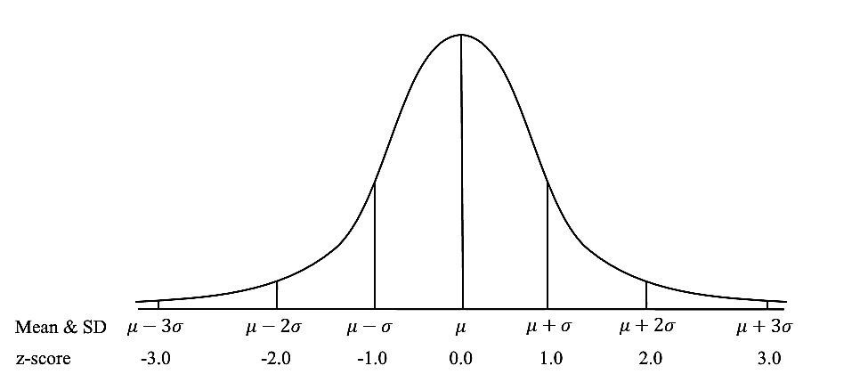

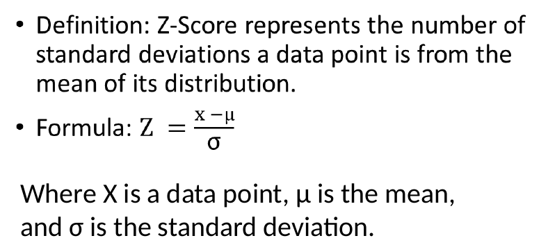

Where X is a data point, μ is the mean, and σ is the standard deviation.

Interpretation:

- A z-score of 0 corresponds to a data point that is exactly at the mean.
- Positive z-scores indicate values above the mean.
- Negative z-scores indicate values below the mean.

### Back to our Empirical Rule Example

A large lecture class has 280 students. The professor has announced that the mean score in an exam is 74 with a standard deviation of 8.

Use the Empirical Rule to answer the following:

- Approximately how many students within 58 and 90?
  - Approximately how many students scored higher than 90?

**Solution for part (b)**

- The score 90 is 2 standard deviations above the mean.
  - Therefore, 97.5% of students are below that value and 2.5% are above it.
  - Consequently, 2.5/100 * 280 = 7 students are above 90.

#### Try this in R

- **Purpose:** Use the stated empirical-rule approximation to calculate expected counts.
- **Before running:** `c()` combines the two calculations. Multiplication by 280 converts a model probability into an expected count. The remaining 5% is divided equally between the two tails of a normal model.

```r
# c() collects the two approximate expected counts, using the original 95% empirical-rule approximation.
# These are normal-model approximations for 280 students, not observed counts.
c(between_58_and_90 = 280*0.95, above_90 = 280*0.025)
```

```
between_58_and_90          above_90
              266                 7
```

**Read the result:** The approximate expected counts are 266 between the limits and 7 above the upper limit. These are not observed class totals.

### Z-Scores Uses in Statistics

- **Standardization**: Z-scores standardize different distributions to be comparable by converting them to a common scale.
- **Identification of Outliers**: Data points with z-scores less than -2 or greater than 2 are often considered outliers.
- **Compare values** from different populations (e.g. exam results between courses).
- **Probabilities and Percentiles**: Z-scores link data points to their probabilities and percentiles in a normal distribution. E.g., a z-score of 1.96 corresponds to the 97.5th percentile.

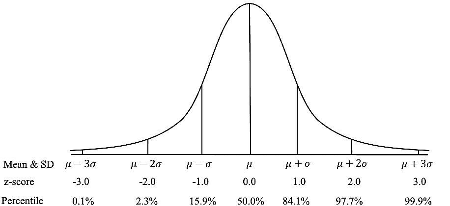

### Z-Scores Example – Comparing Values

Khalid achieved 90 in both Python & Database exams. The mean μ for the Python exam was 70 and σ = 10, The μ for the Database exam was 80 and σ = 10.

Use standard scores to determine where did Khalid achieve a better score.

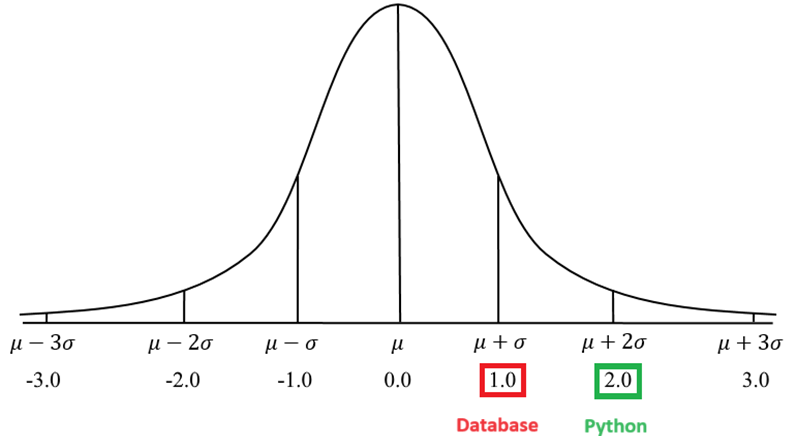

- Standard score for the Python Exam: (90−70)/10 =2
- Standard score for the Database Exam: (90−80)/10 =1
- Khalid's Z-score for the Python exam is 2, which means his score was 2 standard deviations above the mean.
- His Z-score for the Database exam is 1, indicating his score was 1 standard deviation above the mean.
- Khalid performed better on the Python exam than Database exam since his Z-score is higher for that exam.

#### Try this in R

- **Purpose:** Compare the two exam results in SD units.
- **Before running:** Parentheses make subtraction happen first; `/` divides by the course SD. `c()` labels the two standardised scores. A z-score is a relative position, not automatically a normal percentile.

```r
# Standardization subtracts the stated course mean and divides by that course's SD.
# Both exam scores are 90; a larger z-score means a higher position relative to the course mean.
c(Python = (90-70)/10, Database = (90-80)/10)
```

```
  Python Database
       2        1
```

**Read the result:** The scores are 2 and 1 SDs above their respective means. This compares relative positions; it does not establish identical exam difficulty.

### How to Find the Right Distribution

#### Try this in R

- **Purpose:** Compare three candidate models for explicitly simulated data.
- **Before running:** `set.seed()` makes the simulation reproducible. `rnorm(2000,mean=25,sd=8)` generates 2,000 values. `MASS::fitdistr()` fits a specified family; `::` selects a function from the MASS package. `lapply()` applies the anonymous function to each family; `sapply()` extracts their AIC values. `names()` labels them. Lower AIC compares only these candidates.

```r
# set.seed() makes rnorm() reproducible; the 2,000 simulated values use the source mean 25 and SD 8.
# MASS::fitdistr() fits three candidate families by maximum likelihood; this is a limited R comparison.
set.seed(307312)
y <- rnorm(2000, mean=25, sd=8)
# lapply() passes each family name to the anonymous function and collects its fitted model.
fits <- lapply(c("normal","logistic","cauchy"), function(family) MASS::fitdistr(y, family))
# AIC() trades fit against parameter count; lower AIC only compares these candidates, not all distributions.
# sapply() applies AIC to each fitted object; names label the results for interpretation.
aic <- sapply(fits, AIC)
names(aic) <- c("normal","logistic","cauchy")
aic
```

```
  normal logistic   cauchy
13994.51 14044.21 14761.35
```

**Read the result:** These are simulated values, not business observations. The comparison is limited to normal, logistic and Cauchy models; it does not establish a true distribution or check the data-collection design.

Z-Tables

### The Z-Tables

The area under the curve in continuous probability distributions represents the probability of outcome occurrence.

The Empirical Rule has pre-defined areas for certain Z-Scores.

What can we do if we need the area between other Z-Scores e.g. +1.25, -2.33?

It will be hard to compute the integral for different intervals:

A simpler solution would be to use a table of pre-computed areas (The Z-Table).

But we need to compute that area ONCE. Therefore, we need to create a Standard Distribution.

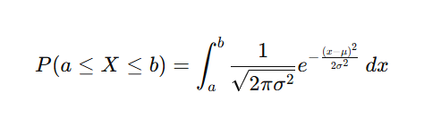

### Standard Normal Distribution and Standard Z Scores

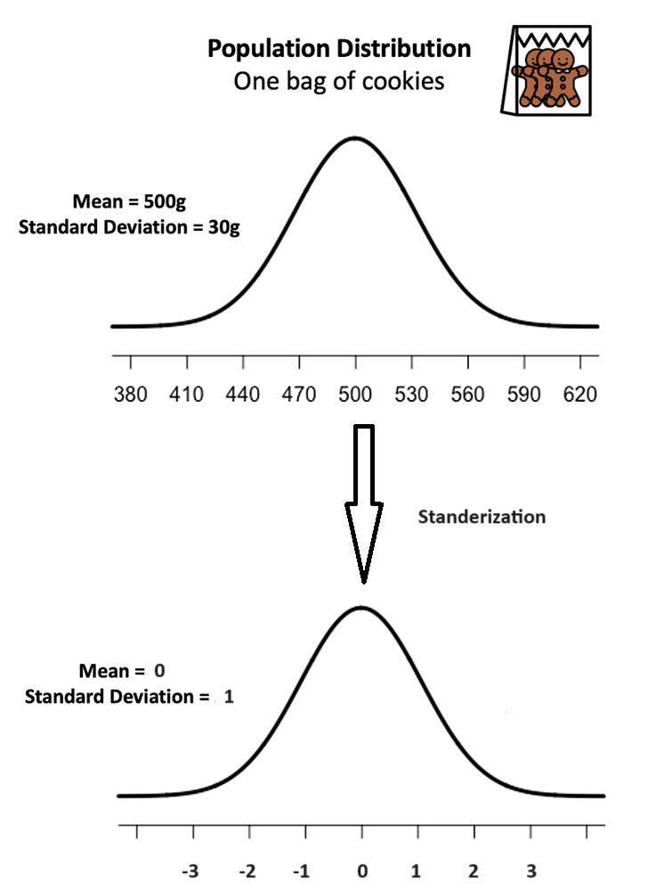

The standard normal distribution is a special case of the normal distribution where the mean is zero and the standard deviation is 1.

This distribution is also known as the Z-distribution.

A value on the standard normal distribution is known as a standard score or a Z-score.

A standard score represents the number of standard deviations above or below the mean that a specific observation falls.

For example, a standard score of 1.5 indicates that the observation is 1.5 standard deviations above the mean.

On the other hand, a negative score represents a value below the average.

The mean has a Z-score of 0.

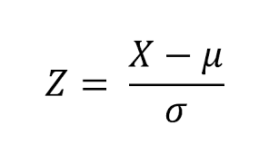

https://medium.com/towards-data-science/what-is-p-value-370056b8244d

**Z-Table for Z Values below 0**

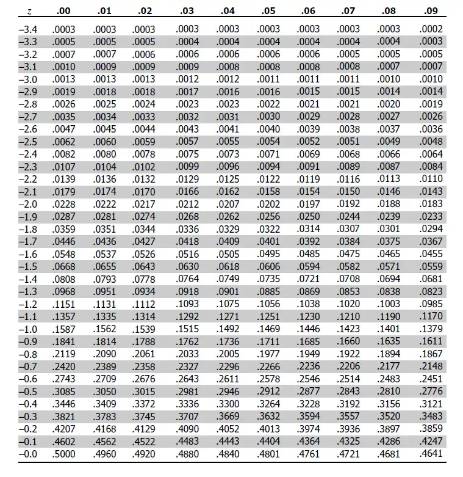

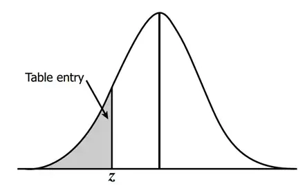

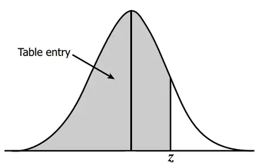

### Z-Tables Example

The average score for the MID exam in Descriptive Statistics course was 70. The standard Deviation for that exam was 6.

Knowing that the exam scores are normally distributed, what is the probability of having a score higher than 75 in that exam?

First, we need to find the standard position (z-score) for the 75 score.

Z score for (75) = (75 – 70) / 6 = 5/6 = .833

Using the z table, the closest value for .833 is: 0.7967 which corresponds to 79.67% of scores are below 75.

To find the probability of having a score over 75, we subtract 79.67% out of the total probability of 100%:

#### Try this in R

- **Purpose:** Find the upper-tail normal probability for the stated score threshold.
- **Before running:** `pnorm(q,mean,sd)` returns a cumulative normal probability. Here the first argument 75 is q, mean is 70 and SD is 6. `lower.tail=FALSE` gives the area above 75.

```r
# pnorm() integrates the stated normal model: mean 70, SD 6, and a score threshold of 75.
# lower.tail=FALSE gives P(score>75) directly, without rounding the z-score to a table entry.
pnorm(75, mean=70, sd=6, lower.tail=FALSE)
```

```
[1] 0.2023284
```

**Read the result:** The model probability is about 0.20233, or 20.233%. A probability and its percentage use different scales.

### Normal probabilities in R

The average score for the MID exam in Descriptive Statistics course was 70. The standard Deviation for that exam was 6.

What is the probability of having a score higher than 90 in that exam?

#### Try this in R

- **Purpose:** Answer this slide’s question: a score above 90.
- **Before running:** `pnorm(q=90,mean=70,sd=6,lower.tail=FALSE)` calculates the upper normal tail. `<-` stores it; `c()` displays it as a probability and after multiplying by 100 as a percentage.

```r
# The question on this slide asks for a score above 90.
p_above_90 <- pnorm(q=90, mean=70, sd=6, lower.tail=FALSE)
c(probability=p_above_90, percentage=100*p_above_90)
```

```
 probability   percentage
0.0004290603 0.0429060333
```